# SOK-1006 v23

## Innleveringsoppgave 2

### Analyse av en merverdiavgift ("ad valorem tax")

Her skal vi se på virkningen av å ilegge en vare en skatt i henhold til dens verdi (merverdiavgift). Betrakt fremstillingen av markedet for oppdrettslaks i læreboka s. 101-104. Etterspørsel er gitt ved

\begin{equation} x^{D}= 500 -3.2p_k\tag{1} \end{equation}

og tilbud:

\begin{equation} x^{S}= -100 + 4.3p_s\tag{2} \end{equation}

Kjøpere betaler $p_k$ og selgere får $p_s$. Prisen som selgere får er det som konsumenter betaler minus mva $tp_k$, noe som betyr at $p_s=(1-t)p_k$. Her er $1>t\geq 0$ avgiftssatsen. Vi kan skrive (2) også som en funksjon på prisen som konsumenten betaler:

\begin{equation} x^{S}= -100 + 4.3 p_k(1-t)\tag{3} \end{equation}

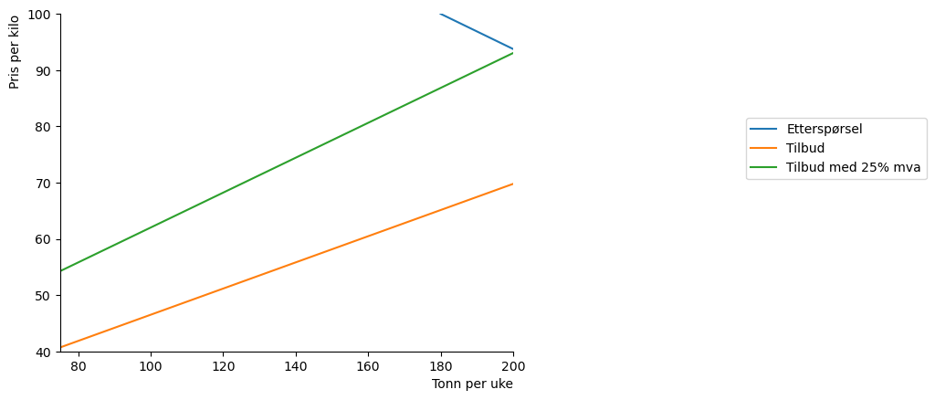

1. Forklar hvorfor tilbudsfunksjonen med mva har brattere helning enn den med t=0.
2. Beregn likevektspris og -kvantum med og uten mva, og vis disse is figuren.
3. Beregn og vis inntekten til staten, og andelen som betales av konsumenter og produsenter.
4. Hva er fordeler/ulemper av en mva og en stykkprisavgift?

### Løsning

1. Desto høyere prisen blir jo mer utgjør 25% mva i NOK (og det er NOK som er enheten på den verikale aksen). Er salgsprisen 10kr får selger 7.5kr (avstand mellom tilbudskurvene er 2.5kr); er salgsprisen 20kr får selger 15kr og avstanden mellom kurvene er 5kr.

$\displaystyle 500 - 3.2 p = 4.3 p \left(1 - t\right) - 100$

$\displaystyle - \frac{6000.0}{43.0 t - 75.0}$

$\displaystyle - \frac{25800.0 \cdot \left(1 - t\right)}{43.0 t - 75.0} - 100$

$\displaystyle - \frac{4500.0}{43.0 t - 75.0}$

$\displaystyle - \frac{1500.0 \left(- \frac{25800.0 \cdot \left(1 - t\right)}{43.0 t - 75.0} - 100\right)}{43.0 t - 75.0}$

$\displaystyle - 0.000666666666666667 \left(-80 - \frac{6000.0}{43.0 t - 75.0}\right) \left(43.0 t - 75.0\right)$

```
0.573333333333333
```

Kjøpere betaler $57\frac{1}{3}\%$ av skatten.

La oss nå beregne likevektsverdiene:

```
Uten mva er prisen 80.0kr og omsatt kvantum 244.0 enheter
Med mva betaler konsumenter 93.39kr
Selgers pris er 70.04kr
Omsatt kvantum med mva er 201.17 enheter
Avgiftproveny er 4696.51kr
```

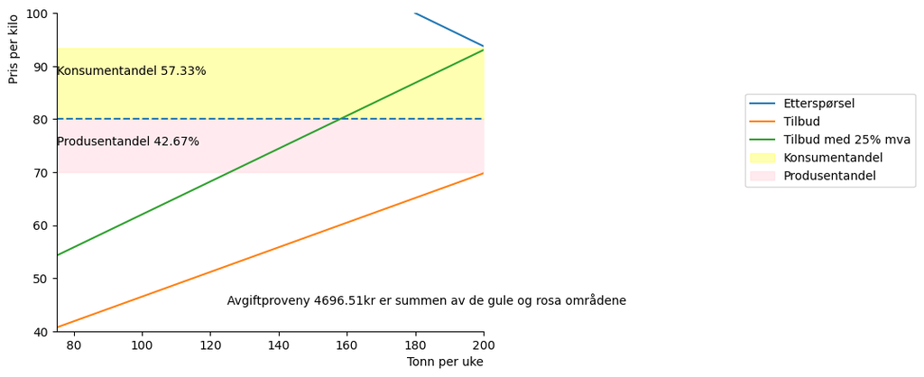